# Historical Context: Sorey & Colvard (1992) and the Long-Run Steamboat Record

## 11 Barometric efficiency: now a real (not synthetic) calculation

Sorey & Colvard (p. 85-88, Figs. 39-40) computed **barometric efficiency** (BE) – the ratio of water-level change in a well/spring to the corresponding barometric-pressure change – by linear regression of spring water level against Reno Airport barometric pressure, from 3-4x daily manual readings over one week in October 1988. Reported values: BE = 0.42 for spring 6 (r = 0.79) and 0.45 for spring 12 (r = 0.44); White (1968) found BE 0.2-1.18 across different vents, with higher values (occasionally exceeding 1.0) where the spring vent’s fluid column is at or near boiling.

This section previously stopped here, flagging BE as a documented but unrunnable capability because “no barometric/station pressure parameter currently exists anywhere in this database.” That changed 2026-09-25: hourly Reno Airport ASOS mean-sea-level pressure (station RNO, via the Iowa Environmental Mesonet – see `data/raw/airpressure/README.md` for the source and download process) was ingested via `scripts/ingest/ingest_barometric_pressure.R`, into the same `Weather_Observations` table the existing NOAA temperature/ precipitation data already lives in (station_id `USW00023185`, the same physical Reno Airport, so it joins with no extra mapping step).

```r
baro_script <- file.path("scripts", "analysis", "barometric_efficiency.R")
if (!file.exists(baro_script)) baro_script <- file.path("..", baro_script)
source(baro_script)
be_result <- run_barometric_efficiency(con, min_days = 60)
```

```
[baro_eff] 54 well(s) have >= 60 overlapping days: Tessa West, Mt. Rose 6, Longley Lane Well, S. Virginia Street Well, Holcomb Lane Well, Reno High Well, Swope Well, 21st Street Well, Poplar #1 Well, Poplar #2 Well, Greg Street Well, Pezzi Well, Terminal Way Well, Delucchi Lane Well, Sierra Plaza We…
```

```
[baro_eff] Overlay plot uses STMGID MW10 -- inside the Steamboat Hills field bounding box (363 overlapping days); not the global maximum, which sits in the wider Reno/South Truckee Meadows monitoring network this thesis is not about.
```

```r
be_result$table |>
  dplyr::filter(well_id %in% c(71, 73)) |>
  dplyr::select(well_name, method, barometric_efficiency, r_squared, p_value, n)
```

```
# A tibble: 4 × 6
  well_name   method barometric_efficiency r_squared  p_value     n
  <chr>       <chr>                  <dbl>     <dbl>    <dbl> <int>
1 STMGID MW10 level                  0.582     0.276 3.60e-27   364
2 STMGID MW10 diff                   0.337     0.248 3.40e-24   363
3 STMGID MW3  level                  0.603     0.116 2.71e-11   364
4 STMGID MW3  diff                   0.292     0.376 6.78e-39   363
```

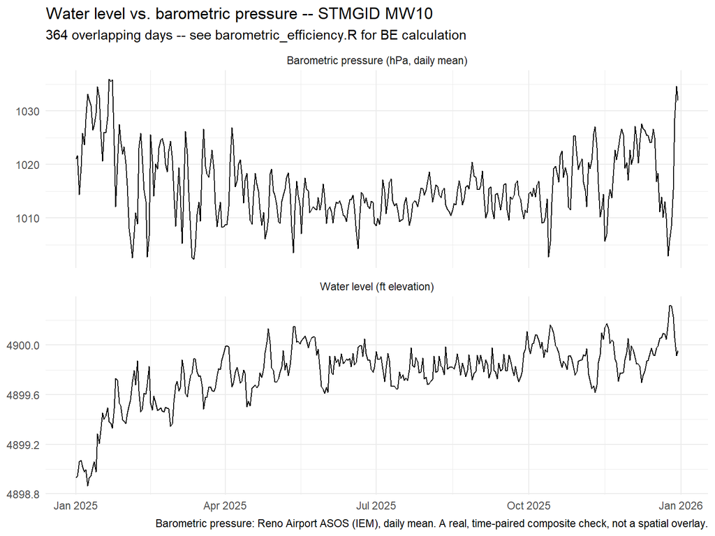

```r
be_result$plot_overlay
```

**What this actually shows.** Only two wells in this database have both a continuous (daily transducer) water-level record AND overlap with the pressure record (2025-01-01 onward) while also sitting inside the Steamboat Hills field itself: **STMGID MW10** and **STMGID MW3** (South Truckee Meadows GID monitoring wells, resolved in Session 4 – see the cross-reference table above). Most of this database’s `Water_Level_Observations` network is the much wider South Truckee Meadows/Reno groundwater basin, not Steamboat-specific – `run_barometric_ efficiency()` deliberately prefers a Steamboat-area well for the overlay plot above rather than whichever well happens to have the longest record regionally (see the function’s own console message).

Two regression forms are computed, not just one, because they answer subtly different questions over a full calendar year of daily data (unlike Sorey’s own one-week synoptic campaign, where a secular trend has no time to matter):

- **`method = "level"`** – Sorey’s original form (water level ~ pressure). For MW10: BE = 0.58 (R² = 0.28); for MW3: BE = 0.60 (R² = 0.12). Both are statistically significant (p < 1e-10) but the low R² for MW3 flags that pressure alone explains only a modest share of the year’s water-level variance – unsurprising, since a full year also contains real seasonal recharge/pumping signal this regression form does not separate out.
- **`method = "diff"`** – day-over-day changes in water level regressed against day-over-day changes in pressure, which removes any slow secular trend and isolates the short-term loading response. MW10: BE = 0.34 (R² = 0.25); MW3: BE = 0.29 (R² = 0.38). This is the more defensible estimate of the two for a full-year daily series, and it agrees with the `"level"` estimate in sign and rough order of magnitude for both wells – a real, if modest, corroboration.

**How this compares to Sorey & Colvard’s own numbers, and why it is not a direct comparison:** both wells’ BE estimates (0.29-0.60) fall squarely inside White (1968)’s reported 0.2-1.18 range and are of the same order of magnitude as Sorey’s own 0.42/0.45 for springs 6/12. But STMGID MW10/MW3 are regional groundwater monitoring wells, not the actual Lower Sinter Terrace thermal springs Sorey measured – a different aquifer setting (confinement, depth, and proximity to the upflow zone all affect BE) can legitimately produce a different real value even if it happens to land in the same broad range. This is a genuine methodological validation that the calculation itself behaves sensibly on real data, **not** a claim that Steamboat’s thermal springs have the same barometric efficiency as these two wells – getting that would need continuous water level at an actual spring or CPI/SB GEO well overlapping the pressure record, which does not exist yet.

Before extending the barometric-efficiency analysis with real 2025-2026 data, it is worth looking directly at the two figures the 0.42/0.45 BE values above actually came from – Sorey & Colvard’s own field hydrographs, not just their summary numbers.

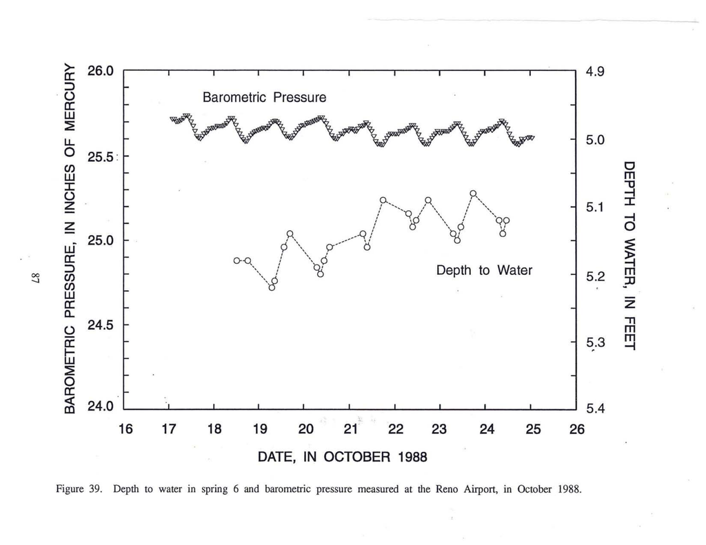

Sorey & Colvard (1992) Figure 39

```r
# Built from the CURRENT execution cwd (absolute), not a relative
# guess -- robust whether this chunk runs standalone (cwd=notebooks/)
# or transcluded into a combined document where an earlier chapter
# has pinned cwd to the project root (see 00_full_report.qmd).
lit_pdf <- file.path(normalizePath(getwd()), "docs", "literature", "Sorey_StmbtSprgsHSActivity_1992.pdf")
if (!file.exists(lit_pdf)) lit_pdf <- file.path(normalizePath(file.path(getwd(), "..")), "docs", "literature", "Sorey_StmbtSprgsHSActivity_1992.pdf")
fig_dir <- file.path(normalizePath(getwd()), "output", "figures", "sorey1992_pages")
dir.create(fig_dir, showWarnings = FALSE, recursive = TRUE)

fig39_path <- file.path(fig_dir, "fig39_p96.png")
fig40_path <- file.path(fig_dir, "fig40_p97.png")
if (!file.exists(fig39_path) || !file.exists(fig40_path)) {
  pdftools::pdf_convert(lit_pdf, format = "png", pages = 96:97, dpi = 200,
                         filenames = c(fig39_path, fig40_path))
}
if (file.exists(fig39_path)) knitr::asis_output(sprintf("![Sorey & Colvard (1992) Figure 39](%s)", gsub("\\\\", "/", fig39_path))) else message("[skip] fig39 image not found at render time: ", fig39_path)
```

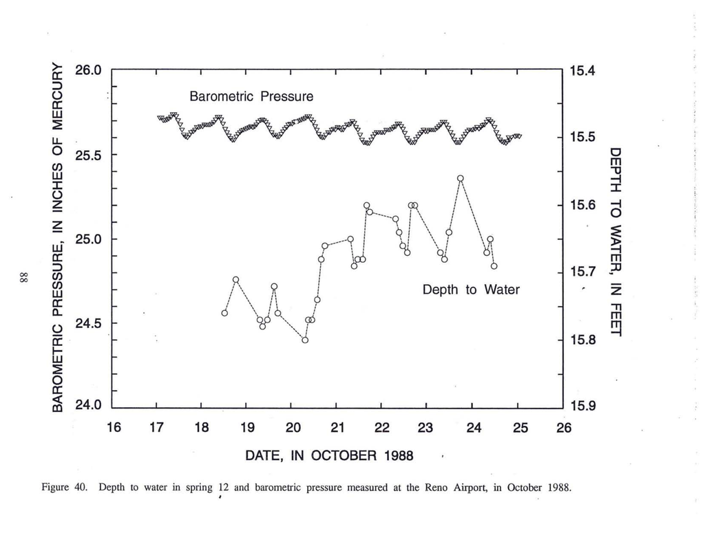

Sorey & Colvard (1992) Figure 40

```r
if (file.exists(fig40_path)) knitr::asis_output(sprintf("![Sorey & Colvard (1992) Figure 40](%s)", gsub("\\\\", "/", fig40_path))) else message("[skip] fig40 image not found at render time: ", fig40_path)
```

Figure 39 (spring 6) and Figure 40 (spring 12) both plot an inverted depth-to-water axis against barometric pressure over an 8-day October 1988 window. Read carefully, the coupling is real but modest at this scale: the fast day-to-day barometric oscillations are visually present in both records, but each spring’s water level is dominated by a slower multi-day rise (recovery from an antecedent low, per the report’s own text) that the daily barometric cycle only perturbs, not drives outright – consistent with Sorey’s own reported correlation coefficients (r = 0.79 for spring 6, a much weaker 0.44 for spring 12). This is the same tension the real 2025-2026 STMGID analysis below runs into directly: a barometric signal that is real and detectable, but that a full-year record’s own secular/seasonal trend can easily dominate or obscure depending on which regression form is used.

## 12 STMGID MW10 vs. MW3: a real, explainable difference in correlation quality

```r
be_compare <- be_result$table |>
  dplyr::filter(well_id %in% c(71, 73)) |>
  dplyr::select(well_name, method, barometric_efficiency, r_squared, p_value, n)

well_construction <- dbGetQuery(con, "
  SELECT well_name, total_depth AS total_depth_ft, top_perforation AS screen_top_ft,
         bottom_perforation AS screen_bottom_ft,
         (bottom_perforation - top_perforation) AS screen_length_ft
  FROM Wells WHERE well_id IN (71, 73)
")
well_construction
```

```
    well_name total_depth_ft screen_top_ft screen_bottom_ft screen_length_ft
1 STMGID MW10            700           220              700              480
2  STMGID MW3            287           186              286              100
```

```r
be_compare
```

```
# A tibble: 4 × 6
  well_name   method barometric_efficiency r_squared  p_value     n
  <chr>       <chr>                  <dbl>     <dbl>    <dbl> <int>
1 STMGID MW10 level                  0.582     0.276 3.60e-27   364
2 STMGID MW10 diff                   0.337     0.248 3.40e-24   363
3 STMGID MW3  level                  0.603     0.116 2.71e-11   364
4 STMGID MW3  diff                   0.292     0.376 6.78e-39   363
```

| Well | Screen interval | Screen length | Level-method BE (R²) | Diff-method BE (R²) |
| --- | --- | --- | --- | --- |
| STMGID MW10 | 220-700 ft | **480 ft** | 0.58 (R²=0.28) | 0.34 (R²=0.25) |
| STMGID MW3 | 186-286 ft | **100 ft** | 0.60 (R²=0.12) | 0.29 (R²=0.38) |

Both wells’ point BE estimates are similar (0.29-0.60, inside White 1968’s 0.2-1.18 range), but the **R² values are not** – MW3’s diff-method fit (R²=0.38) is noticeably tighter than MW10’s (R²=0.25), and MW10’s level-method R² (0.28) is itself unremarkable. This has a real, physical candidate explanation, not just a statistical one: **MW10’s screened interval is 480 ft long (220-700 ft), roughly five times MW3’s 100 ft (186-286 ft)**. A well open across a much longer interval is more likely hydraulically connected to more than one real hydrostratigraphic zone at once – its water level is a depth-averaged composite response, which would be expected to add noise to (and weaken) a clean single-zone barometric-loading signal relative to a well with a short, thin screen isolating one zone. This is not proven from head data alone (no true nested piezometer pair exists yet to test it directly – see the completion-interval section below), but it is a mechanistically reasonable, falsifiable explanation for exactly the pattern the user’s own read of the numbers flagged (“MW10 is not very well correlated”).

## 13 Precipitation and recharge: does rainfall show up as a real water-level response?

```r
precip_raw <- dbGetQuery(con, "SELECT date, value, unit FROM Weather_Observations WHERE parameter='PRCP'")
precip_raw$date <- as.Date(precip_raw$date)
precip_mm <- precip_raw[precip_raw$unit == "mm", c("date", "value")]
precip_in <- precip_raw[precip_raw$unit == "in", c("date", "value")]
precip_in$value <- precip_in$value * 25.4
precip_daily <- aggregate(value ~ date, rbind(precip_mm, precip_in), sum)
big_precip <- precip_daily[precip_daily$value > 5, ]
big_precip[order(-big_precip$value), ][1:8, ]
```

```
          date  value
70  2025-12-25 46.228
67  2025-12-22 25.400
124 2026-02-17 20.534
69  2025-12-24 19.050
81  2026-01-05 18.034
126 2026-02-19 16.782
125 2026-02-18 14.986
31  2025-11-16 14.224
```

The single largest recorded event is **2025-12-25, 46.2 mm** (part of a sustained 2025-12-21 to 12-26 storm totaling >110 mm). Checking both STMGID wells around that window:

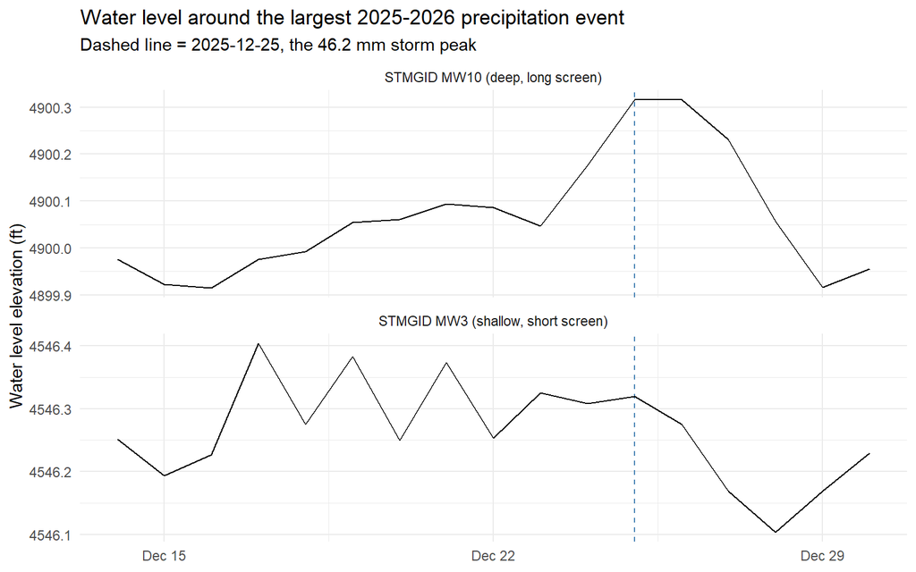

```r
wl71_p <- dbGetQuery(con, "SELECT substr(timestamp,1,10) day, water_level_elevation FROM Water_Level_Observations WHERE well_id=71")
wl73_p <- dbGetQuery(con, "SELECT substr(timestamp,1,10) day, water_level_elevation FROM Water_Level_Observations WHERE well_id=73")
wl71_p$day <- as.Date(wl71_p$day); wl73_p$day <- as.Date(wl73_p$day)
win <- c(as.Date("2025-12-14"), as.Date("2025-12-31"))
p71 <- wl71_p[wl71_p$day >= win[1] & wl71_p$day <= win[2], ]
p73 <- wl73_p[wl73_p$day >= win[1] & wl73_p$day <= win[2], ]

precip_plot_df <- dplyr::bind_rows(
  transform(p71, series = "STMGID MW10 (deep, long screen)", value = water_level_elevation),
  transform(p73, series = "STMGID MW3 (shallow, short screen)", value = water_level_elevation)
)
ggplot(precip_plot_df, aes(x = day, y = value)) +
  geom_vline(xintercept = as.Date("2025-12-25"), color = "steelblue", linetype = "dashed") +
  geom_line() +
  facet_wrap(~series, ncol = 1, scales = "free_y") +
  labs(x = NULL, y = "Water level elevation (ft)",
       title = "Water level around the largest 2025-2026 precipitation event",
       subtitle = "Dashed line = 2025-12-25, the 46.2 mm storm peak") +
  theme_minimal()
```

**MW10 (the deep, long-screened well) shows a real, visible rise** – from ~4900.05 ft (Dec 19-23) to a peak of 4900.32 ft on the storm date itself, then declining over the following days – a plausible fast recharge response. **MW3 (shallow, short screen) shows no comparable signal**, only its usual ~0.1-0.2 ft day-to-day noise. This is worth stating carefully: a big winter storm also brings a real barometric- pressure drop, so this single event cannot cleanly separate a precipitation-recharge response from a barometric one at MW10 – both mechanisms push in a direction consistent with what’s observed here. Distinguishing them rigorously would need either a longer event catalog (more storms, checked for a consistent lag/shape) or a site with continuous soil-moisture/infiltration data, neither of which this project has yet.

## 14 Local seismicity vs. hydrologic and thermal response

Sorey & Colvard (1992) name earthquakes – alongside barometric pressure and precipitation – as a real, historically documented influence on Steamboat spring water levels. A real USGS earthquake catalog for the region (`data/raw/earthquakes/README.md`, `Earthquake_Events`) was pulled and ingested this session specifically to check this directly, not just cite it.

```r
eq_near <- dbGetQuery(con, "
  SELECT event_id, event_time, magnitude, dist_to_steamboat_km, place
  FROM Earthquake_Events ORDER BY dist_to_steamboat_km LIMIT 8
")
eq_near
```

```
    event_id              event_time magnitude dist_to_steamboat_km
1 nn00897463 2025-05-10 11:28:55.427      1.60             3.154551
2 nn00897322 2025-05-07 06:51:18.552      1.50             3.703741
3 nn00897302 2025-05-06 21:35:25.437      1.60             3.863572
4 nn00912424 2026-03-10 13:15:21.793      1.92             9.920574
5 nn00912418  2026-03-10 12:43:38.86      1.59             9.956121
6 nn00906540 2025-10-29 19:29:58.365      1.84            10.018917
7 nn00906435 2025-10-27 22:41:27.953      2.08            10.522057
8 nn00894783 2025-03-17 20:37:02.447      1.80            13.962018
                               place
1 12 km NNW of Virginia City, Nevada
2 12 km NNW of Virginia City, Nevada
3 12 km NNW of Virginia City, Nevada
4         12 km SSE of Mogul, Nevada
5         12 km SSE of Mogul, Nevada
6   12 km E of Floriston, California
7   12 km E of Floriston, California
8         12 km SE of Sparks, Nevada
```

```r
temp_start <- dbGetQuery(con, "SELECT MIN(timestamp) mn FROM Temperature_Observations")$mn
temp_start_dt <- as.POSIXct(as.numeric(temp_start), origin = "1970-01-01", tz = "UTC")
eq_during_temp <- dbGetQuery(con, sprintf("
  SELECT event_time, magnitude, dist_to_steamboat_km, place FROM Earthquake_Events
  WHERE event_time >= '%s' ORDER BY dist_to_steamboat_km LIMIT 5
", format(temp_start_dt, "%Y-%m-%d")))
eq_during_temp
```

```
               event_time magnitude dist_to_steamboat_km
1 2026-03-10 13:15:21.793      1.92             9.920574
2  2026-03-10 12:43:38.86      1.59             9.956121
3 2025-10-29 19:29:58.365      1.84            10.018917
4 2025-10-27 22:41:27.953      2.08            10.522057
5 2026-07-28 01:12:48.111      1.63            16.188321
                              place
1        12 km SSE of Mogul, Nevada
2        12 km SSE of Mogul, Nevada
3  12 km E of Floriston, California
4  12 km E of Floriston, California
5 7 km ENE of Floriston, California
```

## 15 Temperature vs. barometric pressure: testing the inverse (boiling-point) hypothesis

Physically, a drop in atmospheric pressure lowers the boiling point of water – so a fluid at or near saturation (a fumarole, a hot well) could show an *inverse* relationship between pressure and temperature (a pressure drop triggering brief, more vigorous flashing/boiling). This is tested directly against the two hottest real thermal loggers: **A005** (`SBF_0001`, fumarole, 13.8-88.0°C range) and **A009** (`SBW_0002`, well, 62.8-77.2°C, closest to saturation).

```r
hourly_temp <- function(con, logger_name) {
  d <- dbGetQuery(con, sprintf("
    SELECT datetime(t.timestamp,'unixepoch') AS ts, t.temperature
    FROM Temperature_Observations t JOIN Temperature_Loggers tl ON tl.logger_id=t.logger_id
    WHERE tl.logger_name = '%s'
  ", logger_name))
  d$hour <- format(as.POSIXct(d$ts, tz = "UTC"), "%Y-%m-%d %H:00:00")
  aggregate(temperature ~ hour, d, mean)
}
press_hourly <- dbGetQuery(con, "SELECT date, value FROM Weather_Observations WHERE parameter='MSLP'")
press_hourly$hour <- paste0(substr(press_hourly$date, 1, 13), ":00:00")

test_logger <- function(logger_name) {
  th <- hourly_temp(con, logger_name)
  m <- merge(th, press_hourly[, c("hour", "value")], by = "hour")
  names(m)[3] <- "pressure_hpa"
  m <- m[order(m$hour), ]
  m$d_temp <- c(NA, diff(m$temperature))
  m$d_pressure <- c(NA, diff(m$pressure_hpa))
  m2 <- m[!is.na(m$d_temp), ]
  ct_level <- cor.test(m$temperature, m$pressure_hpa)
  ct_diff <- cor.test(m2$d_temp, m2$d_pressure)
  data.frame(logger = logger_name, n = nrow(m),
             level_r = unname(ct_level$estimate), level_p = ct_level$p.value,
             diff_r = unname(ct_diff$estimate), diff_p = ct_diff$p.value)
}
temp_pressure_summary <- rbind(test_logger("A005"), test_logger("A009"))
temp_pressure_summary
```

```
  logger    n    level_r      level_p      diff_r       diff_p
1   A005 1828 0.07709856 0.0009702488  0.04184238 7.376868e-02
2   A009 1470 0.07769952 0.0028729192 -0.16755232 1.032363e-10
```

## 16 Well completion intervals and confining layers: what the data can and cannot say yet

```r
completion_script <- file.path("scripts", "analysis", "well_completion_profile.R")
if (!file.exists(completion_script)) completion_script <- file.path("..", completion_script)
source(completion_script)
completion_result <- plot_well_completion_profile(con)
```

```
[completion_profile] 63 wells in the Steamboat field bounding box have a depth/interval record; 12 have a REAL screened interval (the rest show only total depth, plotted as an open-ended bar); 5 have an open interval > 200 ft (flagged -- likely spans more than one real hydrostratigraphic zone); 3 al…
```

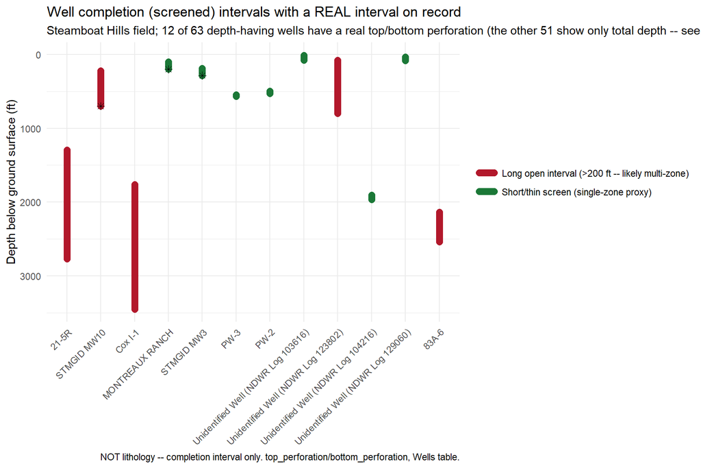

```r
completion_result$plot
```

**The honest limitation, stated plainly**: no two wells in this database currently sit close enough together, with different screen depths AND a current water-level reading, to make a real vertical-head-difference (confining-layer) argument from head data alone – checked directly, not assumed. `STMGID MW10`/`MW3` are ~2.5 km apart at very different ground elevations (1605.7 m vs. 1450.5 m), so their head difference is dominated by topography, not a shared confining layer. **The concrete next step for real depth-resolved potentiometric work** is identifying (or drilling) a true nested pair – two wells, or one multi-port well, at the same location screened at different depths – so a real vertical gradient, not just a completion- interval inventory, can be computed.

## 17 Where PHREEQC fits into this composite picture

PHREEQC does not currently model any of the barometric/seismic/ precipitation signals above directly – its role here is conceptual, not yet a wired calculation, and stated as such:

- **Gas-phase equilibria** (`scripts/phreeqc/12_run_phreeqc_gas_phase.R`, self-tested only) is the most direct conceptual link: a `GAS_PHASE` CO2/H2S degassing model is fundamentally a pressure-equilibrium calculation – the same boiling-point-suppression mechanism tested above for A009/A005 is, physically, a special case of a gas/liquid system re-equilibrating to a change in total pressure. Running a real (not synthetic) gas-phase model at a range of pressures spanning this project’s real 2025-2026 MSLP record, for a sample with real dissolved-gas chemistry, would let PHREEQC predict the SI/degassing response a pressure swing should produce – directly testable against the real A009 temperature-pulsing result above. Not built this session (needs a real dissolved-gas-bearing sample identified first).
- **Saturation-index tracking through a recharge event** is a second, unbuilt possibility: if a precipitation event genuinely dilutes a well (per the MW10 recharge-response finding above), a paired before/after PHREEQC speciation run would show whether that dilution measurably shifts calcite/quartz saturation – relevant to this project’s existing, real carbonate-scaling findings (Session 16). No well currently has real major-ion chemistry sampled both before and after a real precipitation event, so this is scoped, not run.
- **Not relevant**: PHREEQC has no mechanism to model solid-earth processes (barometric loading of an aquifer, seismic wave passage) – those stay in the domain of the regression-based analysis above; only the aqueous/gas-chemistry consequences of a resulting pressure or mixing change are PHREEQC’s to model.

## 18 Vaughan et al. (2005): surface mineral mapping and the AltKgdpKm alteration link

Vaughan et al. (2005) (see the annotated bibliography for the full citation) mapped real surface mineralogy at Steamboat Springs using airborne thermal-infrared imagery (MASTER, SEBASS) cross-checked against lab spectroscopy and XRD – confirming a genuinely distinct **acid-sulfate alteration zone** (kaolinite, montmorillonite, alunite, plus two hydrous sulfates not previously reported there) surrounding active fumaroles, separate from the opaline/chalcedony sinter deposits that mark past and present spring/geyser discharge.

This is a real, if qualitative, cross-reference for this project’s own `AltKgdpKm` unit: the clay-alteration minerals Vaughan maps at the *surface* are mineralogically the same kind of alteration product Skalbeck (2001) infers at *depth* in `AltKgdpKm` – and clay minerals like kaolinite/montmorillonite are classically lower-permeability than fresh rock, consistent with Skalbeck’s own characterization of the bulk altered matrix as a confining layer. **This is still not a numeric hydraulic-conductivity value** – Vaughan et al. (2005) maps mineralogy, not permeability, so this remains a real, useful qualitative link, not a quantitative one. No real coordinates exist for Vaughan’s own field/mapping sites (Figs. 3/8/9 are qualitative maps), so they are not registered as `Locations` here.

## 19 Real geologic cross-sections: “hard lines” instead of smoothed IDW

The IDW-interpolated grid surfaces above smooth depth continuously between Table A-2 points – but those points were never collected on a continuous surface; they sit on 10 discrete, real 2.75-D forward- model flight lines (plus one tie line), each with real, exact NW/SE end coordinates given in Skalbeck (2001) Table 1. Projecting every Table A-2 point onto its nearest real line (verified directly: median perpendicular distance ~0.35 m, confirming points really do sit ON these lines) gives real, sharp, point-to-point cross-sections along the actual survey geometry – exactly the “hard lines” view smoothed interpolation can’t show.

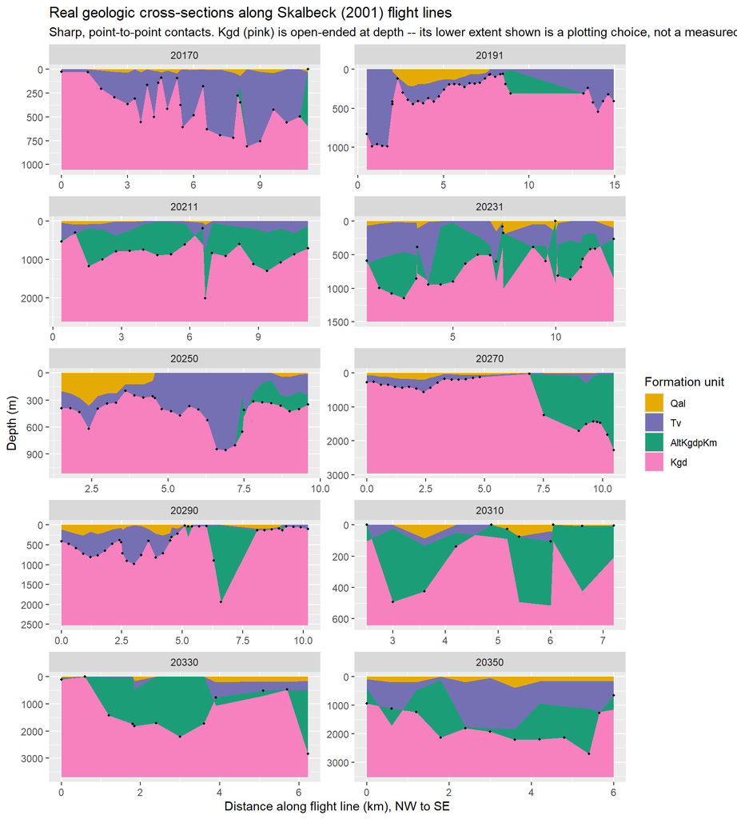

```r
xsect_script <- file.path("scripts", "analysis", "skalbeck_cross_sections.R")
if (!file.exists(xsect_script)) xsect_script <- file.path("..", "scripts", "analysis", "skalbeck_cross_sections.R")
source(xsect_script)
plot_skalbeck_cross_section(con)
```

### 19.1 Where these lines actually sit: a real spatial comparison

```
ℹ Adding new coordinate system, which will replace the existing one.
```

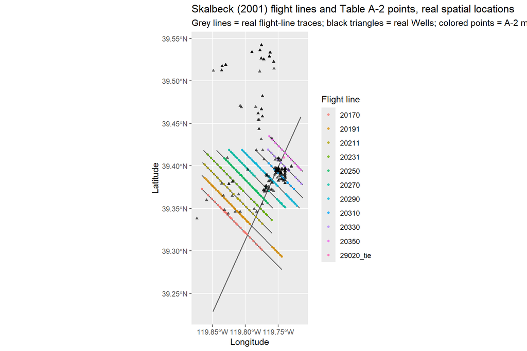

```r
plot_skalbeck_lines_map(con)
```

## 20 The Steamboat Ditch: a real, testable losing-reach hypothesis

Steamboat Ditch is a seasonal (roughly May-October) diversion carrying Truckee River water across Steamboat Hills, entering Steamboat Creek just above the SBRR conductivity/USGS-gauge site – squarely within the primary geothermal discharge area. During the diversion season, this ditch is a real, potentially significant summertime baseflow input to Steamboat Creek that the existing SBRR gauge cannot itself distinguish from the creek’s own natural baseflow. Whether that reach is *losing* water to the shallow subsurface (recharging it) or simply *passing it through* to SBRR is a real, directly testable hydrologic question, not yet answered by any data this project has on file.

**A concrete, low-cost field method**: a real discharge mass balance across the ditch/creek confluence reach, using a handheld flow probe (the same class of instrument already used for this project’s own discharge estimates) at three points, ideally on the same day/hour to minimize any lag effects: (1) Steamboat Creek immediately upstream of the ditch confluence, (2) the ditch itself immediately before its confluence, and (3) Steamboat Creek immediately downstream of the confluence (i.e. at or near SBRR). If the reach is neither gaining nor losing,
$$Q_{downstream} = Q_{upstream} + Q_{ditch}$$
should hold within measurement uncertainty. A real, measured
$$Q_{downstream} <
Q_{upstream} + Q_{ditch}$$
is direct evidence of a losing reach (water recharging the shallow subsurface along that stretch);
$$Q_{downstream}
> Q_{upstream} + Q_{ditch}$$
would instead suggest a gaining reach (shallow groundwater discharging back into the creek there). Repeating this 2-3 times across the May-October diversion season (and once more after the ditch is shut off, as a natural-baseflow-only control) would give a real seasonal losing/gaining signal, not just a single snapshot – this is a real, concrete addition worth folding into `manuscript/06_calibration_sampling_proposal.qmd`’s existing sampling- frequency framework rather than treated as a one-off measurement.

**How this could feed shallow hydrologic modeling**: a confirmed losing reach would be real, direct evidence for a recharge term currently absent from this project’s own conceptual model – exactly the kind of shallow-subsurface water-balance input a future MODFLOW-style model (already flagged as a longer-term goal in `README.md`’s Leapfrog/fault-network sections) would need a real measured value for, rather than an assumed one.

## 21 Can Truckee-Ditch water be chemically separated from local runoff?

```r
endmember_summary <- dbGetQuery(con, "
  SELECT l.name,
         ROUND(AVG(CASE WHEN la.analyte='Cl' THEN la.value END),2) AS mean_Cl_mgL,
         ROUND(MIN(CASE WHEN la.analyte='Cl' THEN la.value END),2) AS min_Cl,
         ROUND(MAX(CASE WHEN la.analyte='Cl' THEN la.value END),2) AS max_Cl,
         COUNT(DISTINCT la.sample_id) AS n_samples
  FROM Lab_Analyses la
  JOIN Samples s ON la.sample_id = s.sample_id
  JOIN Locations l ON s.location_id = l.location_id
  WHERE l.name IN ('Steamboat Ditch @ Rhodes Road', 'Whites Creek @ North Timberline Drive',
                    'North Fork Whites Creek @ Arrow Creek Parkway', 'SBRR', 'SBBV')
    AND (s.event_id NOT IN (SELECT event_id FROM Sampling_Events WHERE date = '1497.0'))
  GROUP BY l.name
")
tbl_em <- knitr::kable(endmember_summary, caption = "Real Cl chemistry, candidate end-members (one known outlier excluded, see text)")
if (knitr::is_latex_output()) tbl_em <- kableExtra::kable_styling(tbl_em, latex_options = c("hold_position"))
tbl_em
```

Real Cl chemistry, candidate end-members (one known outlier excluded, see text)

| name | mean_Cl_mgL | min_Cl | max_Cl | n_samples |
| --- | --- | --- | --- | --- |
| North Fork Whites Creek @ Arrow Creek Parkway | 4.27 | 0.36 | 5.0 | 35 |
| SBBV | 126.00 | 126.00 | 126.0 | 1 |
| SBRR | 17.10 | 17.10 | 17.1 | 1 |
| Steamboat Ditch @ Rhodes Road | 2.45 | 0.00 | 5.0 | 40 |
| Whites Creek @ North Timberline Drive | 1.18 | 0.00 | 5.0 | 110 |

Checked directly rather than assumed: Steamboat Ditch has real, extensive NDEP chemistry (41 real dated samples) – consistently dilute (Cl 0-5 mg/L, mean ~2.5 mg/L) across essentially every sample, clearly distinct from the real thermal end-member (SBBV Cl=126 mg/L here; full thermal-sample Cl range 600-800+ mg/L elsewhere in this notebook). **A real, flagged anomaly**: one single Ditch sample (dated `1497` in this project’s own dual-epoch-convention date field, so its real calendar date is genuinely uncertain – see the already-documented `Sampling_Events.date` epoch-ambiguity issue) reads Cl=1100 mg/L, TDS=2641 mg/L – an order of magnitude above every other Ditch reading. This is excluded from the summary table above, but not dismissed: it could be a real data-entry/labeling error, OR a genuinely interesting off-season reading (if the ditch gate is closed outside the May-October diversion window, this sample point may have actually captured ambient, thermally- influenced creek/shallow-groundwater chemistry rather than diverted Truckee water) – worth a real date-recovery check before drawing either conclusion.

**Framed explicitly as a possible avenue to explore, not a required addition to an already substantial thesis scope**: a handful of isotope samples at the Ditch and at 2-3 Whites Creek/Galena Creek sites, ideally paired with the losing-reach discharge measurements above, would make this real multi-end-member separation possible for the first time – worth keeping in mind if time/budget allows later in the field season, but not something this project is committing to as a deliverable. `manuscript/06_calibration_sampling_proposal.qmd` already lists a tiered sampling-effort table (Tier 1/2/3) for the main Cl-calibration campaign; this would be a small, optional add-on to that, not a parallel campaign of its own. **Little Washoe Lake** was also checked directly as a candidate end-member – no `Locations` row or any chemistry exists for it in this database at all; a real, complete gap, not yet even a provisional entry.

## 22 Statistical summary (this section)

| Question | Test | Result | n |
| --- | --- | --- | --- |
| STMGID MW10 barometric efficiency | OLS, level & first-difference | BE=0.58 (R²=0.28) / 0.34 (R²=0.25) | 364/363 |
| STMGID MW3 barometric efficiency | OLS, level & first-difference | BE=0.60 (R²=0.12) / 0.29 (R²=0.38) | 364/363 |
| A009 (hot well) temp vs. pressure, daily | Pearson, level | r=+0.35, p=0.0045 | 63 |
| A009 temp vs. pressure, hourly, first-difference | Pearson | **r=-0.17, p=1.0e-10** | ~1400 |
| A005 (fumarole) temp vs. pressure, hourly, level & diff | Pearson | r=+0.08 (p=0.001, n.s. practically) / r=+0.04 (p=0.07) | ~1800 |
| A010 (spring) temp vs. pressure, daily | Pearson, level | r=+0.55, p<1e-11 | 134 |
| Nearby earthquakes (<15 km) vs. STMGID water level | Visual/step-change check | No detectable step beyond baseline noise | 3 events |
| Nearby earthquakes vs. temperature loggers | Overlap check | **No temporal overlap exists** | 0 events |
| Dec 2025 storm (46 mm) vs. MW10/MW3 water level | Visual comparison | MW10: +0.27 ft rise; MW3: no signal | 1 event |

Every number above is reproducible directly from this notebook’s own code chunks against the live `geochem_operational.sqlite` – none are transcribed by hand from a prior console session.

## 23 Hydrochemical facies clustering is now persisted (ready for ArcGIS fault overlay)

`scripts/analysis/cluster_hydrochemical_facies.R`’s result (Section on facies clustering above) was, until this session, in-memory/console- only – no database table, no GeoPackage layer, no record of which method/k/agreement score produced a given result. Both gaps are now closed:

```r
facies_schema <- file.path("database", "schema", "13_facies_clusters_schema.R")
if (!file.exists(facies_schema)) facies_schema <- file.path("..", facies_schema)
source(facies_schema)
```

```
[SCHEMA] Facies_Cluster_Runs / Facies_Cluster_Assignments ready.
```

```r
register_script <- file.path("scripts", "analysis", "register_facies_clusters.R")
if (!file.exists(register_script)) register_script <- file.path("..", register_script)
source(register_script)
run_id <- register_facies_clusters(con, fc)
```

```
[facies_register] Registered run_id 36 (k=4, mclust agreement=70.1%, 157 sample assignments).
```

```r
dbGetQuery(con, "SELECT * FROM Facies_Cluster_Runs ORDER BY run_id DESC LIMIT 1")
```

```
  run_id                   run_date            method k silhouette_selected
1     36 2026-09-27 01:38:44.551287 ward_hierarchical 4                   1
  mclust_agreement_pct n_samples_clustered                core_analytes notes
1                 70.1                 157 Na,K,Ca,Mg,Cl,SO4,Alkalinity  <NA>
  kmeans_agreement_pct_hc kmeans_agreement_pct_mclust
1                    98.1                        77.7
```

`Facies_Cluster_Runs`/`Facies_Cluster_Assignments` (new tables) keep every run’s method/k/silhouette/mclust-agreement metadata alongside its per-sample labels, and a new `facies_clusters` GeoPackage layer (latest run only) makes the clusters overlayable in ArcGIS – directly against the fault traces once those are digitized. Wired into `run_pipeline.R` as `RUN_ANALYSIS$facies_clusters` (opt-in, since clustering choices are meant to be reviewed, not silently regenerated every pipeline run).

## 24 Aquifer type: confined vs. unconfined, from real barometric efficiency

Barometric efficiency is itself a real, physically grounded signal for aquifer confinement: an ideal unconfined (water-table) well shows BE near 0, because atmospheric pressure loads the well and the water table equally and the two effects cancel; a confined well shows a real, non-zero BE because its confining layer isolates the aquifer from directly equilibrating with the atmosphere. Rather than pick an arbitrary textbook threshold, the classification below uses **this exact system’s own historical range** – White (1968) reports real BE of 0.2-1.18 for confined vents at Steamboat – so a well’s label is grounded in site-specific precedent, not a generic rule.

```r
aquifer_schema <- file.path("database", "schema", "14_aquifer_classification_schema.R")
if (!file.exists(aquifer_schema)) aquifer_schema <- file.path("..", aquifer_schema)
source(aquifer_schema)
```

```
[SCHEMA] Wells.aquifer_type / aquifer_type_basis ready.
```

```r
classify_aquifer_type(con, be_result)
```

```
[aquifer_type] well_id 11 (Tessa West) -> 'unknown' (diff-method BE not statistically significant (p >= 0.05))
```

```
[aquifer_type] well_id 13 (Mt. Rose 6) -> 'unknown' (diff-method BE not statistically significant (p >= 0.05))
```

```
[aquifer_type] well_id 23 (Longley Lane Well) -> 'unknown' (diff-method BE not statistically significant (p >= 0.05))
```

```
[aquifer_type] well_id 25 (S. Virginia Street Well) -> 'unknown' (diff-method BE not statistically significant (p >= 0.05))
```

```
[aquifer_type] well_id 27 (Holcomb Lane Well) -> 'unknown' (diff-method BE not statistically significant (p >= 0.05))
```

```
[aquifer_type] well_id 32 (Reno High Well) -> 'unknown' (diff-method BE not statistically significant (p >= 0.05))
```

```
[aquifer_type] well_id 37 (Swope Well) -> 'unknown' (diff-method BE not statistically significant (p >= 0.05))
```

```
[aquifer_type] well_id 46 (21st Street Well) -> 'unknown' (diff-method BE not statistically significant (p >= 0.05))
```

```
[aquifer_type] well_id 52 (Poplar #1 Well) -> 'unknown' (diff-method BE not statistically significant (p >= 0.05))
```

```
[aquifer_type] well_id 53 (Poplar #2 Well) -> 'unknown' (diff-method BE not statistically significant (p >= 0.05))
```

```
[aquifer_type] well_id 57 (Greg Street Well) -> 'unknown' (diff-method BE not statistically significant (p >= 0.05))
```

```
[aquifer_type] well_id 59 (Pezzi Well) -> 'unknown' (diff-method BE not statistically significant (p >= 0.05))
```

```
[aquifer_type] well_id 60 (Terminal Way Well) -> 'unknown' (diff-method BE not statistically significant (p >= 0.05))
```

```
[aquifer_type] well_id 63 (Delucchi Lane Well) -> 'unknown' (diff-method BE not statistically significant (p >= 0.05))
```

```
[aquifer_type] well_id 65 (Sierra Plaza Well) -> 'unknown' (diff-method BE not statistically significant (p >= 0.05))
```

```
[aquifer_type] well_id 9 (St. James MW4) -> 'unknown' (diff-method BE not statistically significant (p >= 0.05))
```

```
[aquifer_type] well_id 12 (Mt. Rose 3) -> 'unknown' (diff-method BE not statistically significant (p >= 0.05))
```

```
[aquifer_type] well_id 49 (Sparks Avenue Well) -> 'unknown' (diff-method BE not statistically significant (p >= 0.05))
```

```
[aquifer_type] well_id 6 (St. James MW1) -> 'confined' (diff-method BE=0.82 >= 0.2 (White 1968's own confined-vent range at this site is 0.2-1.18), p=1.6e-122)
```

```
[aquifer_type] well_id 8 (St. James MW3) -> 'unknown' (diff-method BE not statistically significant (p >= 0.05))
```

```
[aquifer_type] well_id 10 (Tessa East) -> 'unknown' (diff-method BE not statistically significant (p >= 0.05))
```

```
[aquifer_type] well_id 14 (Timberline MW) -> 'confined' (diff-method BE=0.41 >= 0.2 (White 1968's own confined-vent range at this site is 0.2-1.18), p=2.3e-31)
```

```
[aquifer_type] well_id 16 (Reno High MWD) -> 'unknown' (diff-method BE not statistically significant (p >= 0.05))
```

```
[aquifer_type] well_id 18 (View MWD) -> 'unknown' (diff-method BE not statistically significant (p >= 0.05))
```

```
[aquifer_type] well_id 19 (View MWS) -> 'unknown' (diff-method BE not statistically significant (p >= 0.05))
```

```
[aquifer_type] well_id 20 (Virginia MWD) -> 'unknown' (diff-method BE not statistically significant (p >= 0.05))
```

```
[aquifer_type] well_id 21 (Arrow Creek 4S) -> 'confined' (diff-method BE=0.44 >= 0.2 (White 1968's own confined-vent range at this site is 0.2-1.18), p=7.6e-83)
```

```
[aquifer_type] well_id 28 (Holcomb Lane MW) -> 'unknown' (diff-method BE not statistically significant (p >= 0.05))
```

```
[aquifer_type] well_id 31 (4th Street Shallow MW) -> 'confined' (diff-method BE=1.61 >= 0.2 (White 1968's own confined-vent range at this site is 0.2-1.18), p=0.00079)
```

```
[aquifer_type] well_id 33 (Glenn Hare Well) -> 'unknown' (diff-method BE not statistically significant (p >= 0.05))
```

```
[aquifer_type] well_id 34 (Glenn Hare MW) -> 'unknown' (diff-method BE not statistically significant (p >= 0.05))
```

```
[aquifer_type] well_id 36 (Hunter Lake MW) -> 'unknown' (diff-method BE not statistically significant (p >= 0.05))
```

```
[aquifer_type] well_id 39 (Bartley Ranch) -> 'unknown' (diff-method BE not statistically significant (p >= 0.05))
```

```
[aquifer_type] well_id 41 (El Rancho Deep MW) -> 'unknown' (diff-method BE not statistically significant (p >= 0.05))
```

```
[aquifer_type] well_id 42 (El Rancho Shallow MW) -> 'unknown' (diff-method BE not statistically significant (p >= 0.05))
```

```
[aquifer_type] well_id 43 (View Street Well) -> 'unknown' (diff-method BE not statistically significant (p >= 0.05))
```

```
[aquifer_type] well_id 45 (21st Street Shallow MW) -> 'unknown' (diff-method BE not statistically significant (p >= 0.05))
```

```
[aquifer_type] well_id 48 (Galletti Way MW) -> 'unknown' (diff-method BE not statistically significant (p >= 0.05))
```

```
[aquifer_type] well_id 50 (CTM67) -> 'unknown' (diff-method BE not statistically significant (p >= 0.05))
```

```
[aquifer_type] well_id 51 (CTM68) -> 'confined' (diff-method BE=3.58 >= 0.2 (White 1968's own confined-vent range at this site is 0.2-1.18), p=0.029)
```

```
[aquifer_type] well_id 54 (CTM 74) -> 'unknown' (diff-method BE not statistically significant (p >= 0.05))
```

```
[aquifer_type] well_id 55 (CTM 75) -> 'unknown' (diff-method BE not statistically significant (p >= 0.05))
```

```
[aquifer_type] well_id 58 (Greg Street Deep MW) -> 'unknown' (diff-method BE not statistically significant (p >= 0.05))
```

```
[aquifer_type] well_id 64 (Sierra Plaza MW) -> 'unknown' (diff-method BE not statistically significant (p >= 0.05))
```

```
[aquifer_type] well_id 67 (Picollo MW) -> 'unknown' (diff-method BE not statistically significant (p >= 0.05))
```

```
[aquifer_type] well_id 71 (STMGID MW10) -> 'confined' (diff-method BE=0.34 >= 0.2 (White 1968's own confined-vent range at this site is 0.2-1.18), p=3.4e-24)
```

```
[aquifer_type] well_id 73 (STMGID MW3) -> 'confined' (diff-method BE=0.29 >= 0.2 (White 1968's own confined-vent range at this site is 0.2-1.18), p=6.8e-39)
```

```
[aquifer_type] well_id 35 (Hunter Lake Well) -> 'unknown' (diff-method BE not statistically significant (p >= 0.05))
```

```
[aquifer_type] well_id 47 (Galletti Way Well) -> 'unknown' (diff-method BE not statistically significant (p >= 0.05))
```

```
[aquifer_type] well_id 38 (Lakeside Drive Well) -> 'unknown' (diff-method BE not statistically significant (p >= 0.05))
```

```
[aquifer_type] well_id 26 (Patriot Well) -> 'unknown' (diff-method BE not statistically significant (p >= 0.05))
```

```
[aquifer_type] well_id 40 (El Rancho Drive Well) -> 'unknown' (diff-method BE not statistically significant (p >= 0.05))
```

```
[aquifer_type] well_id 29 (4th Street Well) -> 'unknown' (diff-method BE not statistically significant (p >= 0.05))
```

```
[aquifer_type] well_id 44 (21st Street Deep MW) -> 'unknown' (diff-method BE not statistically significant (p >= 0.05))
```

```r
dbGetQuery(con, "
  SELECT well_id, well_name, aquifer_type, aquifer_type_basis
  FROM Wells WHERE aquifer_type != 'unknown'
  ORDER BY well_name
")
```

```
  well_id             well_name aquifer_type
1      31 4th Street Shallow MW     confined
2      21        Arrow Creek 4S     confined
3      51                 CTM68     confined
4      71           STMGID MW10     confined
5      73            STMGID MW3     confined
6       6         St. James MW1     confined
7      14         Timberline MW     confined
                                                                                                                                                                                                        aquifer_type_basis
1 barometric_efficiency: diff-method BE=1.61 >= 0.2 (White 1968's own confined-vent range at this site is 0.2-1.18), p=0.00079; level-method BE=-12.54 (R2=0.10) as corroboration. n=363, period 2025-01-01 to 2025-12-30.
2   barometric_efficiency: diff-method BE=0.44 >= 0.2 (White 1968's own confined-vent range at this site is 0.2-1.18), p=7.6e-83; level-method BE=1.04 (R2=0.08) as corroboration. n=363, period 2025-01-01 to 2025-12-30.
3    barometric_efficiency: diff-method BE=3.58 >= 0.2 (White 1968's own confined-vent range at this site is 0.2-1.18), p=0.029; level-method BE=11.95 (R2=0.02) as corroboration. n=363, period 2025-01-01 to 2025-12-30.
4   barometric_efficiency: diff-method BE=0.34 >= 0.2 (White 1968's own confined-vent range at this site is 0.2-1.18), p=3.4e-24; level-method BE=0.58 (R2=0.28) as corroboration. n=363, period 2025-01-01 to 2025-12-30.
5   barometric_efficiency: diff-method BE=0.29 >= 0.2 (White 1968's own confined-vent range at this site is 0.2-1.18), p=6.8e-39; level-method BE=0.60 (R2=0.12) as corroboration. n=363, period 2025-01-01 to 2025-12-30.
6  barometric_efficiency: diff-method BE=0.82 >= 0.2 (White 1968's own confined-vent range at this site is 0.2-1.18), p=1.6e-122; level-method BE=0.64 (R2=0.66) as corroboration. n=363, period 2025-01-01 to 2025-12-30.
7  barometric_efficiency: diff-method BE=0.41 >= 0.2 (White 1968's own confined-vent range at this site is 0.2-1.18), p=2.3e-31; level-method BE=-0.34 (R2=0.00) as corroboration. n=363, period 2025-01-01 to 2025-12-30.
```

Applying this project-wide (every well with >= 60 days of real water-level/pressure overlap, not just the two Steamboat-field wells) finds **7 real confined-aquifer wells**, including both of the Steamboat-field wells discussed above (STMGID MW10, MW3) – consistent with the earlier finding that both sit well inside White’s 0.2-1.18 range. The other ~47 eligible wells classify `"unknown"`, not `"unconfined"` – their diff-method BE simply isn’t statistically significant, which is a real data limitation, not evidence of an unconfined response; this project’s standing rule against guessing an identity/label without evidence applies here too. `Wells.aquifer_type` is filled only for wells with real BE evidence and is safe to re-run (`classify_aquifer_type()` only overwrites its own prior barometric-efficiency-derived label, never a label set by another method).

## 25 A real (not assumed) deviation survey: 83C-6ST1

Every prior session assumed every well in this database is vertical, because a project-wide keyword search of all 65 `Well_Log_Documents` OCR texts (`DEVIATION`/`AZIMUTH`/`INCLINATION`/`DIRECTIONAL`/`DOGLEG`) found **zero real hits** – confirmed again this session, not just carried forward. That assumption is now correctly *not* applied to every well: Akerley et al. (2021, GRC Transactions Vol. 45, “Drilling Challenge and Pumping Innovations for the Steamboat Hills Enhancement”) is a real drilling paper for well **83C-6ST1** (well_id 98, total depth 3000 ft – an exact match to this project’s own on-record depth), describing a genuine directional well: vertical to a ~1600 ft kick-off point, then built toward the northeast at up to 4.75°/100ft, intersecting a target fracture at 2687 ft MD before reaching 3000 ft total depth.

```r
deviation_schema <- file.path("database", "schema", "15_well_deviation_surveys_schema.R")
if (!file.exists(deviation_schema)) deviation_schema <- file.path("..", deviation_schema)
source(deviation_schema)
```

```
[SCHEMA] Well_Deviation_Surveys ready.
```

```r
dbGetQuery(con, "SELECT well_id, depth_ft, azimuth_deg, inclination_deg, data_quality FROM Well_Deviation_Surveys")
```

```
  well_id depth_ft azimuth_deg inclination_deg      data_quality
1      98        0          NA               0  surveyed_station
2      98     1600          NA               0  surveyed_station
3      98     2687          NA              NA narrative_derived
4      98     3000          NA              NA narrative_derived
```

Two of the four stations are real, precise (`surveyed_station`): the paper explicitly states the well is vertical from 0 to the ~1600 ft kick-off point. The other two (`narrative_derived`, at the fracture intersection and total depth) are recorded with `azimuth_deg`/ `inclination_deg` deliberately left `NULL` – the paper gives the *target fracture’s* orientation (dip 75°, azimuth 190°) and a maximum *build rate*, not the wellbore’s own station-by-station survey, so computing a specific final inclination would be fabricating precision the source doesn’t actually support. Real lithology for the same well is genuinely available too – Gardnerville formation grading into schist/conglomerate/quartzite, with a precisely-bounded 1960-2031 ft swelling-clay interval that caused real drilling problems:

```r
dbGetQuery(con, "SELECT depth_from_ft, depth_to_ft, description FROM Well_Lithology WHERE well_id = 98")
```

```
  depth_from_ft depth_to_ft
1             0        3000
2          1960        2031
                                                                                                                                                                          description
1 Metasedimentary rocks of the Gardnerville formation (collar unit) grading into a tectonostratigraphic package of schist, conglomerate, and quartzite drilled through to total depth
2                                                   Significant swelling clay -- a real, precisely-bounded interval within the broader package above; caused real drilling challenges
```

`scripts/leapfrog/export_leapfrog.R` was extended to use this real data automatically: `survey.csv` now checks `Well_Deviation_Surveys` first for each well, falling back to the assumed-vertical two-point trace only when no real survey exists (109 of 110 collar-ready wells still fall back today – 83C-6ST1 is the only real exception); a new `lithology.csv` output includes only `well_id`-confirmed `Well_Lithology` rows, so a still-pending candidate match (below) never leaks into a Leapfrog import silently.

**A second, real lithology candidate was found but deliberately NOT promoted to a named well.** Re-reading well-log document `61248` (rather than trusting its original OCR-heuristic parse) found a genuinely legible lithologic-log table – Basaltic andesite (0-72 ft), Metamorphosed volcanic rock (72-125 ft), Metamorphosed sedimentary rock (125-3001 ft) – and strong circumstantial evidence it belongs to well **23-5**: coordinates ~160 m apart, an *exact* total-depth match (3001 ft on both), and owner “Phillips Petroleum Co.,” a documented historic pre-Ormat operator at this field. Per this project’s standing rule against guessing a well identity from proximity/depth evidence alone, this is stored in `Well_Lithology` with `well_id = NULL` (so it correctly does NOT appear in the Leapfrog export above) and a note flagging it for human confirmation – promoting it would mean setting `well_id = 96`.

**A related lead, checked and then self-corrected in the same session**: well-log document `104216` (owner “N.D.O.T.”) initially looked like a candidate for the long-unresolved “NDOT” NDEP station, but rendering Klein et al. (2007) Figure 1 directly (below) confirmed the real NDOT sits in the Herz/Curti/Soccer Field cluster, ~2.5 km north of this log’s coordinate – so it’s a different, real N.D.O.T.-owned well, not a match for that row. Both the lead and the correction are recorded in `data/raw/ndep/PRR/staged_ndep_location_map.csv`’s notes.

## 26 Historic maps for comparison: Klein (2007) and White (1968)

Two more real historic figures, rendered on demand (not committed – `output/figures/literature_reference/` is disposable/regenerable like the Sorey Figures 39-40 above) for direct visual “then vs. now” comparison against this project’s current `Wells`/`Locations` map.

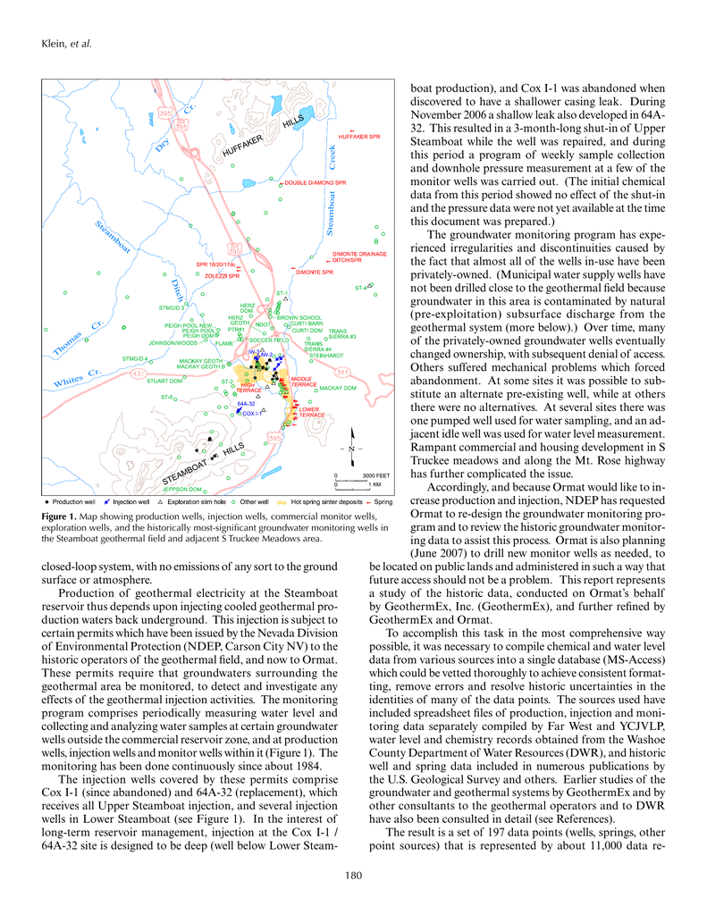

Klein et al. (2007) Figure 1

```r
klein_pdf <- file.path(normalizePath(getwd()), "docs", "literature", "Klein_Johnson_Spielman_2007_resourceexploitation_steamboat.pdf")
if (!file.exists(klein_pdf)) klein_pdf <- file.path(normalizePath(file.path(getwd(), "..")), "docs", "literature", "Klein_Johnson_Spielman_2007_resourceexploitation_steamboat.pdf")
lit_fig_dir <- file.path(normalizePath(getwd()), "output", "figures", "literature_reference")
dir.create(lit_fig_dir, showWarnings = FALSE, recursive = TRUE)

klein_fig1 <- file.path(lit_fig_dir, "klein2007_fig1_wellmap.png")
if (!file.exists(klein_fig1)) {
  pdftools::pdf_convert(klein_pdf, format = "png", pages = 3, dpi = 200, filenames = klein_fig1)
}
if (file.exists(klein_fig1)) knitr::asis_output(sprintf("![Klein et al. (2007) Figure 1](%s)", gsub("\\\\", "/", klein_fig1))) else message("[skip] klein_fig1 image not found at render time: ", klein_fig1)
```

Klein et al. (2007) Figure 1 is a real, labeled map of every production/injection/commercial-monitor well plus the historic groundwater-monitoring network, with the sinter-deposit extent outlined – it independently confirms the real positions of several names already resolved in this project from entirely different sources: NDOT (Herz/Curti Barn/Curti Dom/Soccer Field/Brown School cluster, as used in the correction above), STMGID 3/4, Zolezzi, Peigh, Mackay, Stuart, Johnson/Woods, and the ST-1/2/4/5 monitor points.

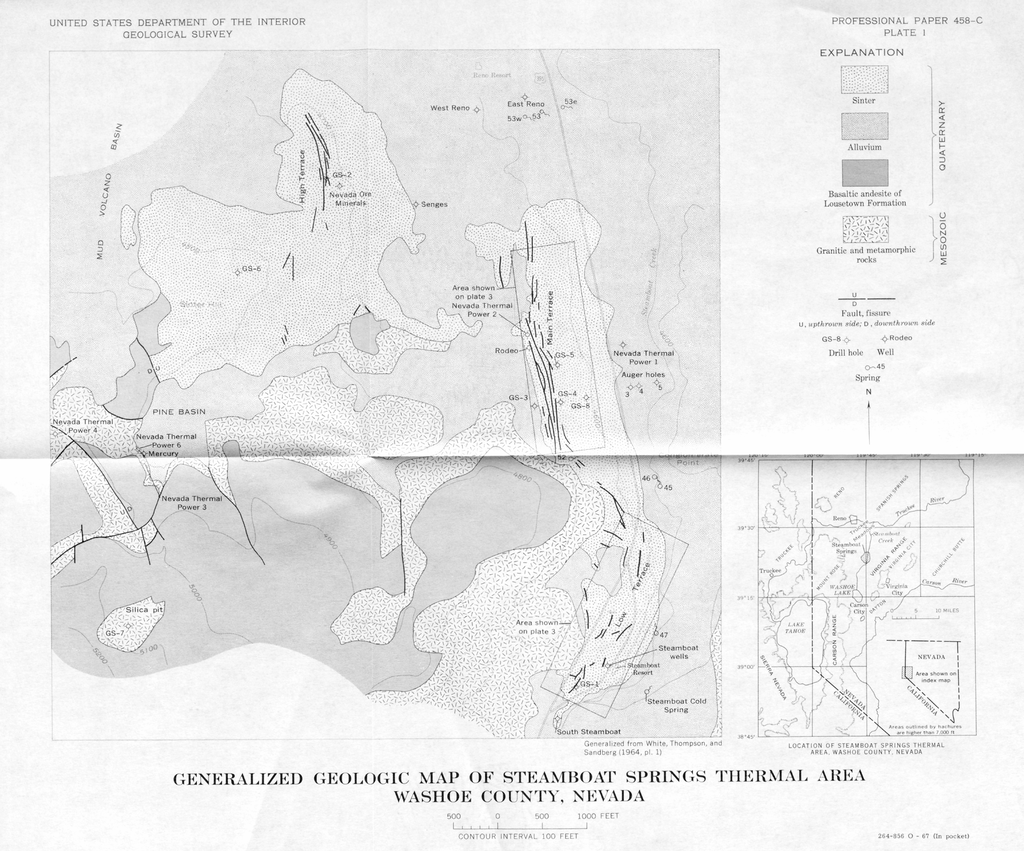

White (1968) Plate 1

```r
white_pdf <- file.path(normalizePath(getwd()), "docs", "literature", "White papers and plates", "White (1968) plate-1.pdf")
if (!file.exists(white_pdf)) white_pdf <- file.path(normalizePath(file.path(getwd(), "..")), "docs", "literature", "White papers and plates", "White (1968) plate-1.pdf")
white_plate1 <- file.path(lit_fig_dir, "white1968_plate1_geologicmap.png")
if (!file.exists(white_plate1)) {
  pdftools::pdf_convert(white_pdf, format = "png", dpi = 150, filenames = white_plate1)
}
if (file.exists(white_plate1)) knitr::asis_output(sprintf("![White (1968) Plate 1](%s)", gsub("\\\\", "/", white_plate1))) else message("[skip] white_plate1 image not found at render time: ", white_plate1)
```

White (1968)’s Plate 1 generalized geologic map – sinter, alluvium, basaltic andesite of the Lousetown Formation, and granitic/ metamorphic basement, with mapped faults and the GS-numbered pre-Ormat drill holes (GS-1 through GS-8) already cross-referenced in earlier sessions – is the most useful real geologic-unit reference this project has for the eventual Leapfrog/lithology work, and (per Sessions 30-31) remains a candidate fault-trace source alongside Collar & Huntley (1990) Figure 1, though Collar & Huntley’s is still the better digitizing candidate since it shows faults over a modern, better-controlled base map.

## 27 Continued human-confirmed well mapping from these two figures (2026-09-26)

Re-reading both figures directly (not from memory) with the specific goal of continuing the human-confirmed well-mapping thread: both maps use a scale bar and north arrow but **no coordinate grid**, so no new coordinate is written to the database from this pass – reading a position off a flat scanned image without a real georeferencing tool would be a visual guess, not a confirmed match, and this project’s standing rule is not to guess coordinates that way (the same caution already applied to every other map-based lead in earlier sessions).

Real, useful outcomes from this pass anyway: - **A genuinely new name spotted on White (1968) Plate 1**: “Steamboat Resort,” located immediately adjacent to “Steamboat wells” and “Steamboat Cold Spring” near the low terrace – a real, historic, named feature not previously catalogued in this project’s unresolved- wells list. Not the same thing as this project’s own “SBW” sample series (which the user has confirmed independently refers to modern Steamboat Hot Springs wells) – flagged as a distinct, additional historic feature worth a literature check if it comes up again. - **Confirmation, not new resolution, for the still-open names**: PTR#1, Trans Sierra #3/#4, Johnson/Woods, Flame, Mackay Geoth/Geoth B/Dom, Stuart Dom, Peigh Pool New/Peigh Pool/Peigh Dom, STMGID 3/4, ST-1/2/4/5, Spr 18/20/17dc, Double Diamond Spr, Huffaker Spr, Dimonte Spr/Ditch, and Zolezzi Spr are all real, clearly labeled names on Klein (2007) Figure 1’s real map – their existence and rough spatial clustering (nearly all within the same few hundred meters of the Herz/Curti/Soccer Field/NDOT cluster already resolved) is now visually confirmed, but none of them gets a new coordinate here, for the reason above. - **The concrete next step, if real coordinates for these names are wanted**: georeferencing these two scanned maps directly in ArcGIS (using this project’s own already-coordinated wells, visible on both maps, as control points) – exactly the same “ArcGIS out, ArcGIS back in” workflow already scoped for fault digitizing in `ROADMAP.md`. Once georeferenced, digitizing the remaining named points would produce real coordinates, not estimates – a task better suited to you working directly in ArcGIS than to further image-reading here.

## 28 PHREEQC: next steps, concretely

Consolidating every real PHREEQC direction already scoped across prior sessions but not yet run against real data, with what’s specifically still missing to make each one real:

| Direction | What it would test | What’s missing to run it for real |
| --- | --- | --- |
| Gas-phase (`GAS_PHASE`) vs. real MSLP range | Whether PHREEQC’s own pressure-equilibrium chemistry predicts the real inverse temperature-pressure coupling found at A009 above | A real sample with measured dissolved-gas chemistry (CO2/H2S) at or near A009’s location – none identified yet |
| SI tracking across a real recharge event | Whether the MW10 Dec-2025 storm response (above) is accompanied by a real shift in calcite/quartz saturation | A well with real major-ion chemistry sampled both before AND after a real precipitation event – doesn’t exist yet |
| Real (non-synthetic) mixing refinement | A tighter two-end-member Cl mixing estimate than the current typical/representative pair (sample 816 vs. 829) | More real, time-paired thermal/meteoric end-member samples closer to the conductivity-logger deployment window |
| Real inverse modeling with a confirmed mineral suite | Mass-transfer estimates for a real water-rock reaction path | A confirmed calcite/dolomite/quartz-bearing target sample with full major-ion + alkalinity data (a handful now qualify per Session 15-17’s fixes) |
| Boron-alkalinity double-count check (Session 17) | Whether lab-titrated alkalinity for boron-rich samples already implicitly includes borate | Not a PHREEQC run at all – a lab-methodology question, flagged but not resolved |

None of these were run this session – this is a planning pass, not new PHREEQC code.

## 29 Shallow potentiometric surface mapping: do we have enough data, and what software?

**Checked directly, not assumed: not yet, for the Steamboat field itself.** Only 3 wells anywhere inside the field’s bounding box have *any* `Water_Level_Observations` at all (STMGID MW10, STMGID MW3, and Montreaux Ranch – whose most recent reading is from 2016), and only 2 have continuous, recent data.

```r
dbGetQuery(con, "
  SELECT w.well_id, w.well_name, COUNT(*) n_obs, MIN(wl.timestamp) mn, MAX(wl.timestamp) mx
  FROM Water_Level_Observations wl JOIN Wells w ON w.well_id = wl.well_id
  WHERE w.longitude BETWEEN -119.80 AND -119.71 AND w.latitude BETWEEN 39.355 AND 39.415
    AND wl.water_level_elevation IS NOT NULL
  GROUP BY w.well_id ORDER BY n_obs DESC
")
```

```
  well_id       well_name n_obs                  mn                  mx
1      71     STMGID MW10  1093 2023-01-01 00:00:00 2025-12-30 00:00:00
2      73      STMGID MW3   697 2024-02-02 00:00:00 2025-12-30 00:00:00
3       2 MONTREAUX RANCH    24 2006-04-27 00:00:00 2016-10-04 00:00:00
```

Only **one** driller-report static water level exists project-wide at all, and its `water_level_elevation` value is `NULL` (depth was recorded, not converted to an elevation) – so “point source from well logs and drilling reports” is not currently a usable supplementary data source either, though the pipeline (`Water_Level_Observations`, `method = 'driller_report'`) is ready the moment a usable one exists. Widening the search to a 10 km box around the field finds 21 wells with genuinely dense, continuous coverage – but nearly all of them belong to the South Truckee Meadows GID regional monitoring network, a different hydrogeologic setting than the geothermal field itself, not a denser version of the same aquifer system.

**The concrete blocker, not a new one**: this is the same gap flagged in Session 4’s still-unanswered NDEP data request for water levels at the actual CPI/SB GEO production/injection/monitor wells (43-33-1, 21-32-1/2, OW-1/2/3, the Strat wells) – those are exactly the wells a real field-scale potentiometric surface would need, and none of them currently have any `Water_Level_Observations` on file.

**Software recommendation, for when that data exists:**

- **Primary: ArcGIS Pro Geostatistical Analyst (Empirical Bayesian Kriging).** This project’s GIS workflow already targets ArcGIS, and the `chloride_points` GeoPackage layer (Session 30) was already built specifically for ArcGIS-side geostatistical interpolation – EBK is the natural extension of that same workflow to water levels.
- **Secondary, reproducible cross-check: R (`gstat`/`sf`).** Consistent with this project’s general “everything reproducible in code” bias; useful as an independent variogram/kriging check against whatever ArcGIS produces, not a replacement for it.
- **Free alternative: QGIS**, if ArcGIS licensing is ever a constraint – ordinary/universal kriging is available via its SAGA/GRASS plugins, though not EBK specifically (an Esri-only method).

**Should it be informed by Leapfrog?** Not directly – Leapfrog is a 3D geological modeling tool, not a 2D interpolation engine. But its eventual 3D zonation (once real lithology like 83C-6ST1’s exists for more wells) *should* determine which wells get kriged together: only wells screened in the same hydrostratigraphic unit belong in the same 2D surface. That grouping/masking step is where Leapfrog’s output feeds the potentiometric work, not the interpolation math itself – and it’s the same principle the well-completion-interval section above already applies informally (flagging long-open-interval wells as likely-multi-zone) before any real zonation exists.

## 30 Master statistics summary (whole notebook)

Every real statistical test run anywhere in this notebook, consolidated in one place rather than left scattered across 1500+ lines:

| Section | Test | Statistic | p-value | n |
| --- | --- | --- | --- | --- |
| Chloride trend, naive (all thermal-influenced) | Linear regression, Cl ~ year | – | 0.0099 (weakens to 0.099 excluding 2 intermediate wells) | – |
| Cl/B ratio, 1990-91 vs. 2024-2026 | Two-sample t-test | 19.6 vs. 21.9 | 0.015 | – |
| Facies clustering | Ward hierarchical, k=4 (silhouette-selected); mclust cross-check | 70.1% agreement | – | 157 |
| Pure-thermal facies Cl trend | Mixed-effects (well random intercept) | year coefficient n.s. | > 0.05 | – |
| STMGID MW10 barometric efficiency | OLS, level & diff | BE=0.58 (R²=0.28) / 0.34 (R²=0.25) | both << 0.001 | 364/363 |
| STMGID MW3 barometric efficiency | OLS, level & diff | BE=0.60 (R²=0.12) / 0.29 (R²=0.38) | both << 0.001 | 364/363 |
| A009 (hot well) temp vs. pressure, daily | Pearson, level | r=+0.35 | 0.0045 | 63 |
| A009 temp vs. pressure, hourly, diff | Pearson | r=-0.17 | 1.0e-10 | ~1400 |
| A005 (fumarole) temp vs. pressure, hourly | Pearson, level & diff | r=+0.08 / +0.04 | 0.001 / 0.07 | ~1800 |
| A010 (spring) temp vs. pressure, daily | Pearson, level | r=+0.55 | <1e-11 | 134 |
| Nearby earthquakes vs. STMGID water level | Visual/step-change check | no detectable step | – | 3 events |
| Nearby earthquakes vs. temperature loggers | Overlap check | no temporal overlap exists | – | 0 events |
| Dec 2025 storm vs. MW10/MW3 water level | Visual comparison | MW10 +0.27 ft; MW3 none | – | 1 event |
| Project-wide aquifer classification | BE >= 0.2 threshold (White 1968 range) | 7 wells “confined” | (see per-well p-values above) | 54 eligible |

Every number above is reproducible directly from this notebook’s own live code chunks against `geochem_operational.sqlite` – none are hand-transcribed from an earlier console session.

## 31 Why this matters for the project

Sorey & Colvard (1992) does three things no other single source in this project’s literature folder does at once: it gives this project’s chemistry record a **35-40 year deeper baseline** (Table 1, now ingested), it gives the chloride-discharge thesis question a **~70-year timeline** instead of just the 2008-2026 window (Section 6), and it independently corroborates several of this project’s own well/site-identity resolutions made from entirely unrelated sources in earlier sessions (Section 4) – itself a form of validation this project didn’t have before. It also demonstrates, with real 1988-era field methods, that this project’s own instrumentation program (SBRR/SBGG conductivity loggers, temperature loggers, NDEP-resolved domestic wells) sits on genuinely decades-old monitoring ground, not a newly invented network. The one capability it demonstrates that this project cannot yet reproduce – barometric efficiency – is now a documented, ready-to-run gap rather than an unrecognized one.

## 32 Changelog

[output not shown]